# Part I - (prosper Loan Dataset )

## by (Ayodele Oluwatosin Joy)

## Investigation Overview

> In this investigation, I wanted to look at the features of loans in the prosper loan data set that could be used to predict the Borrower Annual Percentage Rate.My main focus was on the original loan amount,borrower's rate,Employment Status, borrower's Prosper rating, borrower's Prosper score,loan Term,Lender Yield,income range and estimated return.

## Dataset Overview

> The Prosper Loan Dataset explores a dataset containing 113,937 loans(rows) with 81 variables (columns )on each loan, including loan amount, borrower rate (or interest rate), current loan status, borrower income, borrower employment status, borrower credit history, and the latest payment information.

# Preliminary Wrangling

> Loading my in your dataset using the pandas function with read_csv function and then go ahead to describe its properties through questions i will create below.

### Distribution of Borrower APR

the distribution of the Borrower APR looks multimodal, in such a way that there is a small peak centered at 0.1,at 0.2 there is a large peak centered further more at 0.3 there also a small peak centered.its also safe to say that there is a very shape peak between 0.35 and 0.36. Only very few loans have Borrower APR greater than 0.43.went ahead to analyis and found out there are six(6) borrowers with Borrower APR greater than 0.43 who also have small loan amount.

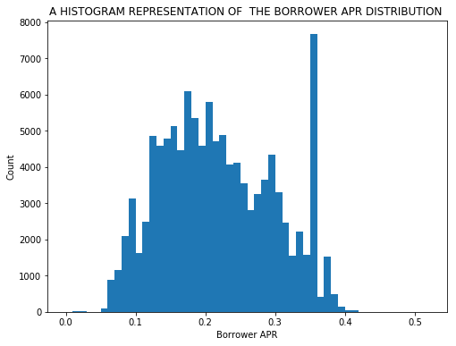

|  | ListingKey | ListingNumber | ListingCreationDate | CreditGrade | Term | LoanStatus | ClosedDate | BorrowerAPR | BorrowerRate | LenderYield | ... | LP_ServiceFees | LP_CollectionFees | LP_GrossPrincipalLoss | LP_NetPrincipalLoss | LP_NonPrincipalRecoverypayments | PercentFunded | Recommendations | InvestmentFromFriendsCount | InvestmentFromFriendsAmount | Investors |
| --- | --- | --- | --- | --- | --- | --- | --- | --- | --- | --- | --- | --- | --- | --- | --- | --- | --- | --- | --- | --- | --- |
| 18326 | 0161336483146123835D6A5 | 1795 | 2006-03-11 15:43:45.393000000 | HR | 36 | Defaulted | 2007-01-14 00:00:00 | 0.45857 | 0.4500 | 0.4325 | ... | -6.62 | 0.00 | 2829.24 | 2829.24 | 0.0 | 1.0 | 0 | 0 | 0.0 | 21 |
| 22195 | 5686336572505607862C0C7 | 1849 | 2006-03-12 13:44:15.060000000 | HR | 36 | Chargedoff | 2009-02-15 00:00:00 | 0.46201 | 0.4500 | 0.4325 | ... | -16.04 | 0.00 | 490.46 | 490.50 | 0.0 | 1.0 | 0 | 0 | 0.0 | 21 |
| 36018 | 844033650124564886B3EDC | 690 | 2006-02-23 13:57:02.087000000 | HR | 36 | Completed | 2006-03-14 00:00:00 | 0.51229 | 0.4975 | 0.4925 | ... | -0.29 | 0.00 | 0.00 | 0.00 | 0.0 | 1.0 | 0 | 0 | 0.0 | 9 |
| 56761 | A79D33661366830833F3EF5 | 2231 | 2006-03-16 19:30:16.753000000 | HR | 36 | Defaulted | 2006-09-19 00:00:00 | 0.50633 | 0.4975 | 0.4800 | ... | -1.27 | 0.00 | 2964.88 | 2964.88 | 0.0 | 1.0 | 0 | 0 | 0.0 | 21 |
| 82043 | BBED336465905564254DC8B | 1112 | 2006-03-02 19:00:17.593000000 | HR | 36 | Defaulted | 2006-09-05 00:00:00 | 0.48873 | 0.4800 | 0.4750 | ... | -1.27 | 0.00 | 2963.64 | 2963.64 | 0.0 | 1.0 | 0 | 0 | 0.0 | 20 |
| 103973 | 95ED3365915044756AB754F | 1366 | 2006-03-06 22:36:53.753000000 | HR | 36 | Defaulted | 2006-10-08 00:00:00 | 0.45857 | 0.4500 | 0.4325 | ... | -3.16 | -3.75 | 2764.01 | 2764.01 | 0.0 | 1.0 | 0 | 0 | 0.0 | 22 |

6 rows × 81 columns

# Distribution of Borrower Rate.

BorrowerRate: the borrow rate which is the Borrower's interest rate for the loan they took. from the above plot,its ok to say it is almost identical to the plot i got for the BorrowerAPR, it just shifted abit to the left. its peak is at around 0.15 and i noticed another peak a little above 0.3, which is the highest peak.

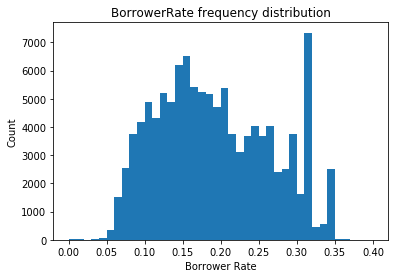